# Final

Oudjedi.cylia

09/01/2020

# Are skilled musicians subject to the McGurk effect?Stephen Politzer-Ahles & Lei Pan.

Department of Chinese and Bilingual Studies, The Hong Kong Polytechnic University, Hung Hom, Hong Kong

```r
library(readr)
data<- read_csv("combined_data.csv")
```

- Le jeu de données a été receuilli dans le cadre d’une éxpérience psycolinguistique sur l’effet McGurk, le but étant de voir si dans les groupes choisis ( musiciens et non musiciens) les musiciens étaient moins sensibles à cet effet optique car étant plus habitués à écouter de la musique et à percevoir des sons. l’éxpérience avait comme sujets des locuteurs natifs de Mandarin ou Cantonais, dévisés en deux groupes: Musiciens avec 13 ans de pratique Non musiciens qui ont indiqué ne pas ecouter de la musique plus d’une heure par jours. ## Explorations des données
- inventaire des variables

```r
names(data)
```

```
##  [1] "Code"          "Fullresp"      "Modality"      "Audio"
##  [5] "Video"         "Resp"          "ProverbioCond" "audPoA"
##  [9] "vidPoA"        "McGurkCond"    "Correct"       "Subject"
## [13] "Group"
```

- Nombre de lignes et de colonnes du Tableau

```r
dim(data)
```

```
## [1] 15805    13
```

- Sur les 13 colonnes, seulement la ligne portant le nom “code” est quantitative, le reste des colonnes sont qualitatives.
  - la colonnes “fullresp” correspond aux réponses données par les sujets. Resp reprend les données de Fullresp mais segmentées en consonnes et en voyelles et non plus comme des syllabes

```r
unique(data$Fullresp)
unique(data$Resp)
```

[output not shown]

- la colonne Modality correspond aux formats des stimulis: audio ou audiovisual

```r
table(data$Modality)
```

```
##
##       audio audiovisual
##        7903        7900
```

- Audio et Video contiennent les consonnes qui ont servis de stimulis en audio et en audiovisuel

```r
table(data$Audio)
```

```
##
##    B    D    F    K    L    M    P    T
## 1973 1980 1974 1975 1973 1978 1974 1976
```

```r
table(data$Video)
```

```
##
##    B    D    F    K    L    M    P    T
## 1978 1974 1972 1975 1976 1978 1973 1977
```

- audPoA et vidPoA contiennent le lieux d’articuations des consonnes présentées en stimulis dans les deux formats audio et audiovisuel

```r
table(data$audPoA)
```

```
##
##    alveolar      labial labiodental       velar
##        5929        5925        1974        1975
```

```r
table(data$vidPoA)
```

```
##
##    alveolar      labial labiodental       velar
##        5927        5929        1972        1975
```

- Correct est une variable Binaire, qui indique si les participants ont réussis l’éxpérience ou non

```r
table(data$Correct)
```

```
##
## FALSE  TRUE
##  3291 12512
```

- Subject correspond aux sujets ayant passés l’éxpérience. résultat de 62 Sujets pour chaque groupe( 62 NM et 62 M)

```r
suj <- data$Subject
unique(suj)
```

```
##   [1] "nm01 mcgurk1.zil"  "nm02 mcgurk2.zil"  "nm03 mcgurk3.zil"
##   [4] "nm04 mcgurk4.zil"  "nm05 mcgurk5.zil"  "nm06 mcgurk6.zil"
##   [7] "nm07 mcgurk7.zil"  "nm08 mcgurk8.zil"  "nm09 mcgurk9.zil"
##  [10] "nm10 mcgurk10.zil" "nm11 mcgurk11.zil" "nm12 mcgurk12.zil"
##  [13] "nm13 mcgurk13.zil" "nm14 mcgurk14.zil" "nm15 mcgurk15.zil"
##  [16] "nm16 mcgurk16.zil" "nm17 mcgurk17.zil" "nm18 mcgurk18.zil"
##  [19] "nm19 mcgurk19.zil" "nm20 mcgurk20.zil" "nm21 mcgurk21.zil"
##  [22] "nm22 mcgurk22.zil" "nm23 mcgurk23.zil" "nm24 mcgurk24.zil"
##  [25] "nm25 mcgurk25.zil" "nm26 mcgurk26.zil" "nm27 mcgurk27.zil"
##  [28] "nm28 mcgurk28.zil" "nm29 mcgurk29.zil" "nm30 mcgurk30.zil"
##  [31] "nm31 mcgurk31.zil" "nm32 mcgurk32.zil" "nm33 mcgurk33.zil"
##  [34] "nm34 mcgurk34.zil" "nm35 mcgurk35.zil" "nm36 mcgurk36.zil"
##  [37] "nm37 mcgurk37.zil" "nm38 mcgurk38.zil" "nm39 mcgurk39.zil"
##  [40] "nm40 mcgurk40.zil" "nm41 mcgurk41.zil" "nm42 mcgurk42.zil"
##  [43] "nm43 mcgurk43.zil" "nm44 mcgurk44.zil" "nm45 mcgurk45.zil"
```

[output cut: 27 more lines]

- Nous avons deux groupes: Musiciens et non musiciens chaque groupe se composent de 62 sujets

```r
table(data$Group)
```

```
##
##    musician nonmusician
##        7869        7936
```

- ProverbioCond et McGurkCond ont en commun les trois conditions suivantes: audio, audiovisual congruent et audiovisual incongruent. cGurkCond sont des conditions prises pour les besoins de cette éxpérience et ProverbioCond sont les conditions prises dans une étude antérieur de Proverbio et al. (2016)

```r
table(data$McGurkCond)
```

```
##
##                   audio   audiovisual congruent audiovisual incongruent
##                    7903                    2468                    5432
```

```r
table(data$ProverbioCond)
```

```
##
##                   audio   audiovisual congruent audiovisual incongruent
##                    7903                     984                    6916
```

## Analyse

- taux de réussite et d’échecs général

```r
library(questionr)
freq(data$Correct)
```

```
##           n    % val%
## FALSE  3291 20.8 20.8
## TRUE  12512 79.2 79.2
## NA        2  0.0   NA
```

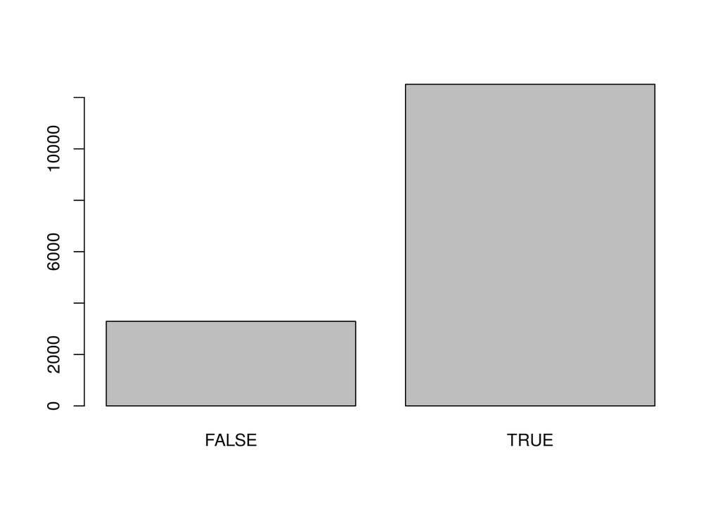

```r
reussite <- table(data$Correct)
barplot(reussite)
```

On observe que le taux de réponse correcte est supérieur à celui des fausses et que le test a dans la globalité était bien réussi par les deux groupes.

```r
install.packages("tidyverse")
library(dplyr)
a <- filter ( data, Group == "nonmusician")#extraire du tableau de donnée les données relatives au groupe des nons musiciens
library(tidyverse)
```

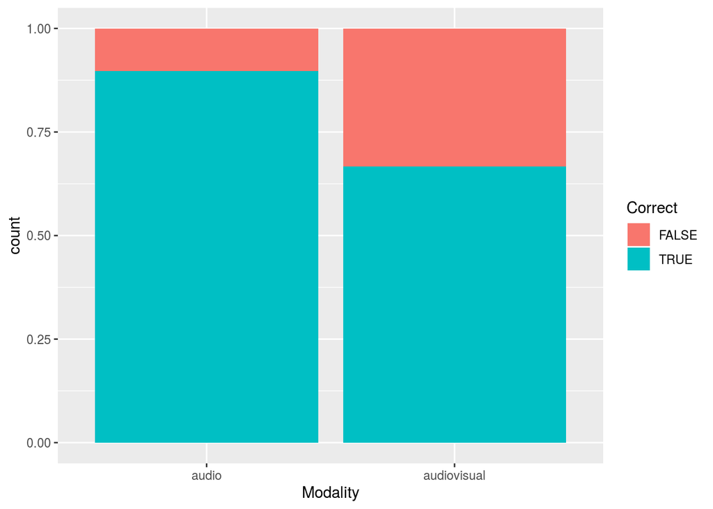

```r
ggplot(a) + geom_bar(position= "fill",aes(x = Modality, fill= Correct))
```

- Le résultat des Musiciens est meilleur en Audio, les graphiques sont relativement similaires.

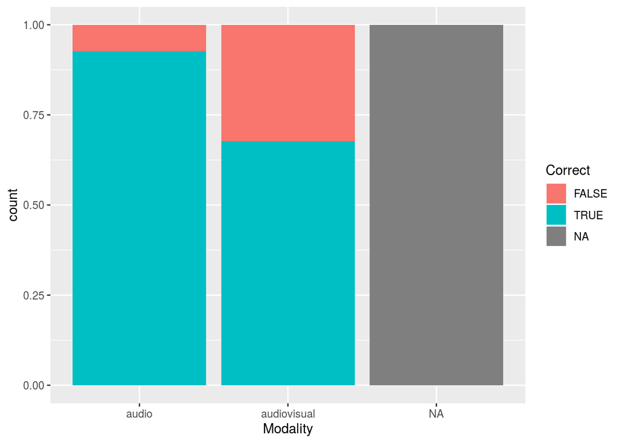

```r
library(dplyr)
b <- filter ( data, Group == "musician")
ggplot(b) + geom_bar(position= "fill",aes(x = Modality, fill= Correct))
```

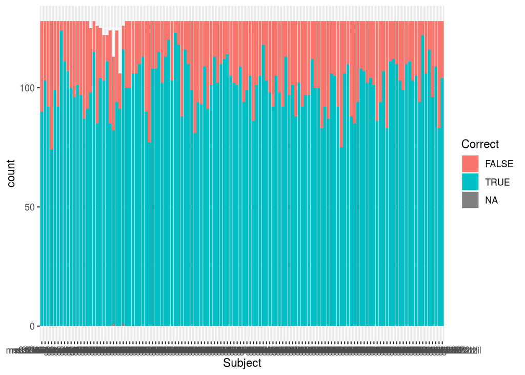

```r
ggplot(data) + geom_bar(aes(x = Subject, fill = Correct))
```

- Dans la globalité, la modalité audio à de meilleurs résultats de bonne réponse pour les deux groupes, comparé à ceux de la modalité Audiovisuel

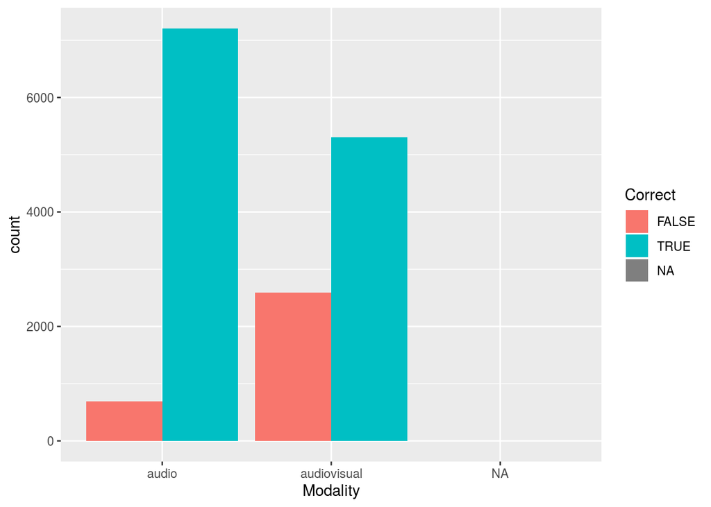

```r
ggplot(data) + geom_bar(aes(x = Modality, fill = Correct), position = "dodge")
```

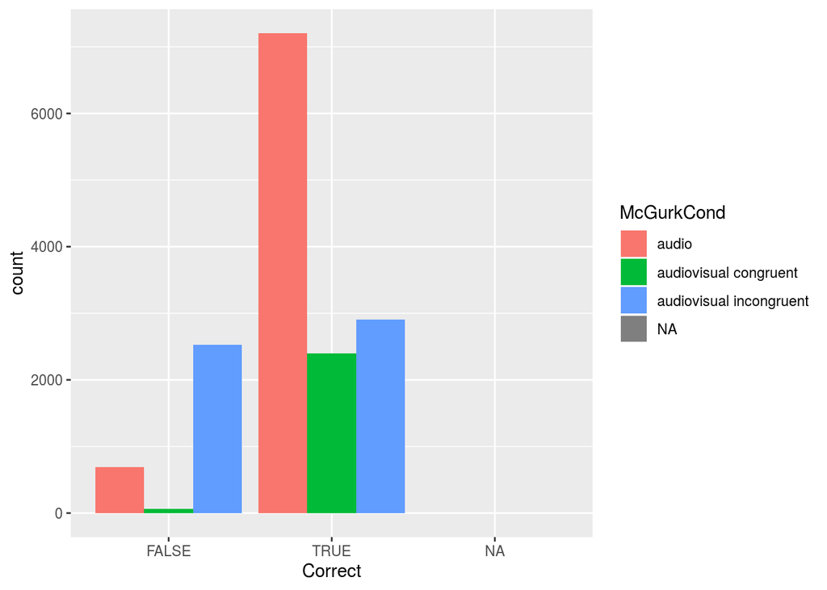

```r
ggplot(data) + geom_bar(aes(x = Correct, fill = McGurkCond), position = "dodge")
```

## Questions

- les données de l’éxpérience nous montrent que les musiciens et les non musiciens ont le même taux de réussite et d’échecs, ce qui reviendrait à dire que le fait d’étre habitué à de la musique n’aide en rien quand le visuel s’en mêle -Une autre analyse intéréssante à faire aurait été de voir les lieux d’articulations des consonnes dans les différents stimulis et de voir si y’a une correlation entre le lieux en Audio et en audiovisuel. C’est à dire voir si l’erreur est dû au fait que les consonnes présentées en audiovisual sont proches d’un point de vue articulatoire, les erreurs viendrait du fait de la proximité du lieux d’articulations des consonnes réalisées
- En terme de stimulis, on pourrait réaliser la même éxperience sans les stimulis audio ou audiovisuels, mais avec des vidéos doublées, c’est à dire que le locuteur1 doublera à l’orale le locuteur 2 qui s’occupera du geste articulatoire, si les locuteur 1 articule correctement et que le locuteur 2 arrive à articuler un autre sons autres que celui de l’audio sans effet de mauvais doublage, on pourrait arriver si dans ce cas précis de doublage ( qui sera bien réalisé)les locuteurs se fie à l’oral ou au visuel.